# Index.R

## Summary

This report focuses on the shootings that occured during 2018, using crowd sourced data. In 2018, there were 340 shootings. The total amount of people injured in shootings during 2018 was 1347 . The total amount of deaths that occured was 373. Some of the most dangerous states in the country include: Illinois, California, and Florida. These states rank in the top 3 in casualties and injuries.

## (Top 10) Most Deaths by City

The table shown below shows the most impacted cities during 2018. The number represented is the number of deaths that have occured as a result. As shown below, with 27 casulaties, Chicago is the deadliest city in 2018.

| City | Number Killed |
| --- | --- |
| Chicago | 27 |
| Philadelphia | 11 |
| Memphis | 9 |
| Saint Louis | 9 |
| New Orleans | 6 |
| Washington | 6 |
| Baltimore | 5 |
| Jacksonville | 5 |
| Los Angeles | 5 |
| Miami | 5 |

## (Top 10) Most Injuries by State

The table shown below shows the states with the most shooting injuries by during 2018.

| State | Number Injured |
| --- | --- |
| Illinois | 150 |
| California | 136 |
| Florida | 132 |
| Tennessee | 68 |
| Pennsylvania | 63 |
| Texas | 62 |
| Alabama | 55 |
| New Jersey | 54 |
| New York | 53 |
| Missouri | 52 |

## Parkland Shooting

On February 14, 2018, one of the [deadliest shootings](https://www.nytimes.com/2018/02/14/us/parkland-school-shooting.html) in recent history took place in Pompano Beach (Parkland), Florida. This shooting took place at Stoneman Douglas High School (5901 Pine Island Rd). This tragic event resulted with a total of 17 people killed and an additional 17 people injured. Since then, the killer has been in custody and is awaiting a trial which will determine whether or not he will recieve the dealth penalty. The aftermath of this event has further increased the debate on the issue of gun control. Proponents of gun control cite this event as one of the reasons why more regulations need to be put in place.

## Map of Shootings in the US

[interactive chart not shown]

This map displays all the shootings that involved deaths during 2018.

## Plot of Choice

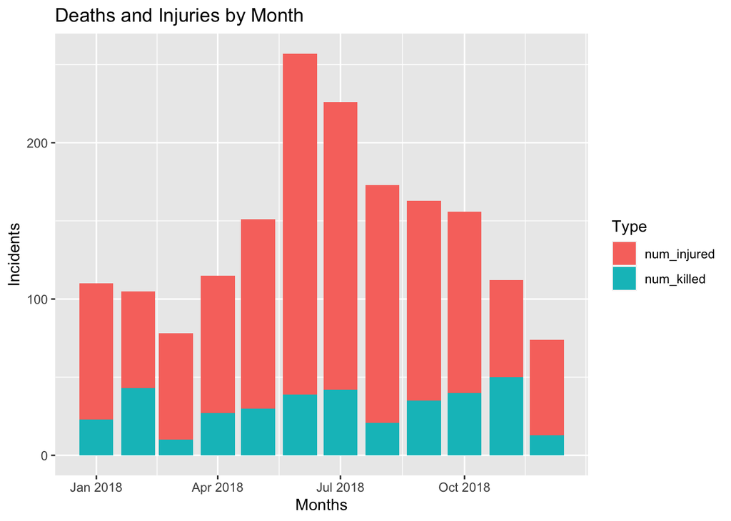

This plot groups the shootings dataset by month. The number of deaths and injuries is then evaluated and compared. As shown on the graph, the number of injuries per month is much greater than deaths per month. The number of injuries peaks towards the middle of the year.